# 6306 Case Study 1

Hollie Gardner & Michael Weatherford

2/17/2020

```r
#install packages
#install.packages("devtools")
#devtools::install_github("wmurphyrd/fiftystater")
#install.packages("ggrepel")

#libraries used
library(ggplot2)
library(imputeTS)
library(dplyr)
library(magrittr)

library(tidyr)
library(stringr)
library(tidyverse)
library(ggrepel)

library(RColorBrewer)
library(statebins)
library(naniar)
library(openintro)
library(fiftystater)
library(maps)
library(mapproj)
library(usmap)
```

# Question 1

**How many breweries are present in each state?**

With no supprises the states with higher populations have a higher number of breweries. The general trend of more breweries for states with higher populations, is due to large populations being able to support a larger beer market. There are more breweries in Democratic states/cities, this indicates that Democrats are more likely to purchase craft beer than Republicans. This trend is consistant with typical younger Democratic voters primarily living on the East and West coast, and older Republican voters living in “fly over” states in the center of the United States. These patterns give us an insight on the demographics of beer drinkers in each state. The younger more Democratic states and cities are more adventerous in try new types of beers with no brand recognition, and the older more republican states are less experimental and are more habitial showing more brand loyality to established and well known breweries.

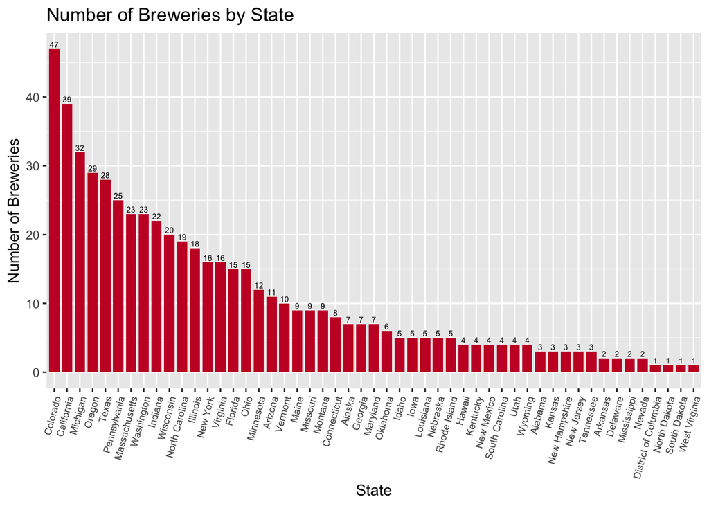

```r
# read in company data
Breweries <- read.csv("~/Desktop/Breweries.csv")

# pulling in state names from maps library
lookup = data.frame(state_code = state.abb, State = state.name) #makes a data frame with State name and state_codereviation.
colnames(Breweries)[4]<- "state_code" # rename column to match lookup data
Breweries$state_code = str_trim(Breweries$state_code) # removing whitespace before each value to merge w/lookup
Breweries = merge(Breweries,lookup,"state_code") # make one dataset with state names and state_code *Lost brewery in DC
Breweries$State <- as.character(Breweries$State)
Breweries = rbind(Breweries, c("DC", 228, "DC Brau Brewing Company", "Washington", "District of Columbia"))

#bar chart for number of breweries by state in order without creating a new dataframe - HG
Breweries %>%
  count(State) %>% #library(plyr) masks dplyr count()
  ggplot(aes(x=reorder(State, -n), y = n)) +
    geom_bar(stat="identity", fill="#C8102E", width=.8) + # budweiser red
    xlab("State") + ylab("Number of Breweries") + ggtitle("Number of Breweries by State") +
    geom_text(aes(label=n), vjust=-0.3, size=2) +
    theme(axis.text.x = element_text(angle = 75, size = 7, hjust = 1))
```

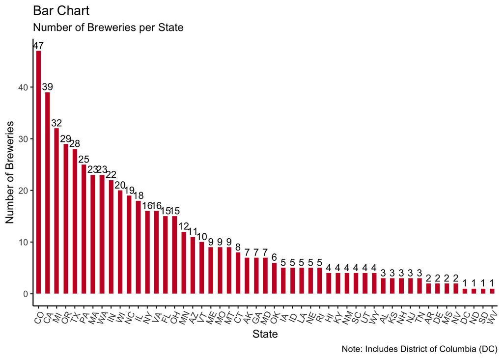

```r
num_state = as.data.frame(table(Breweries$state_code))
colnames(num_state) <- c(as.character("state_code"),"Freq")
num_state$state_code <- as.character(num_state$state_code)
num_state2 <- data.frame("state_code" = as.character(c("AK", "AL", "AR", "AZ", "CA", "CO", "CT", "DC", "DE", "FL", "GA", "HI","IA", "ID", "IL", "IN", "KS", "KY", "LA", "MA", "MD", "ME", "MI", "MN","MO", "MS",  "MT", "NC", "ND", "NE", "NH", "NJ", "NM", "NV", "NY", "OH","OK", "OR", "PA", "PR", "RI", "SC", "SD", "TN", "TX", "UT", "VA", "VT","WA", "WI", "WV", "WY")),"fullState" = as.character(c("Alaska","Alabama" ,  "Arkansas", "Arizona","California" , "Colorado" , "Connecticut", "District of Columbia","Delaware" ,  "Florida" , "Georgia" ,"Hawaii","Iowa" ,"Idaho" , "Illinois" , "Indiana" ,  "Kansas" ,"Kentucky" , "Louisiana" , "Massachusetts", "Maryland" ,"Maine" ,"Michigan" , "Minnesota" , "Missouri" ,"Mississippi" ,  "Montana" ,"North Carolina","North Dakota", "Nebraska" , "New Hampshire" , "New Jersey" ,  "New Mexico" ,"Nevada" ,"New York" , "Ohio" , "Oklahoma" ,"Oregon" , "Pennsylvania" , "Puerto Rico", "Rhode Island" , "South Carolina", "South Dakota" ,"Tennessee" , "Texas" , "Utah" ,  "Virginia","Vermont" ,"Washington" , "Wisconsin", "West Virginia" , "Wyoming")))
num_state = merge(num_state, num_state2, by="state_code")
colnames(num_state)[3] <- "region"
colnames(num_state)[2] <- "Freq"
num_state$region <- as.character(num_state$region)

#Bar Chart for Number of Breweries in Each State - MW
theme_set(theme_classic())
ggplot(num_state, aes(x = reorder(state_code, -Freq), y=Freq)) + geom_bar(stat="identity", width = 0.5, fill="#C8102E") +
  labs(title="Bar Chart",
       subtitle="Number of Breweries per State",
       caption="Note: Includes District of Columbia (DC)") +
  theme(axis.text.x = element_text(angle=65, vjust=0.6)) +
  xlab("State") + ylab("Number of Breweries") +
  geom_text(aes(label=Freq), vjust=-0.3, size=3.5)
```

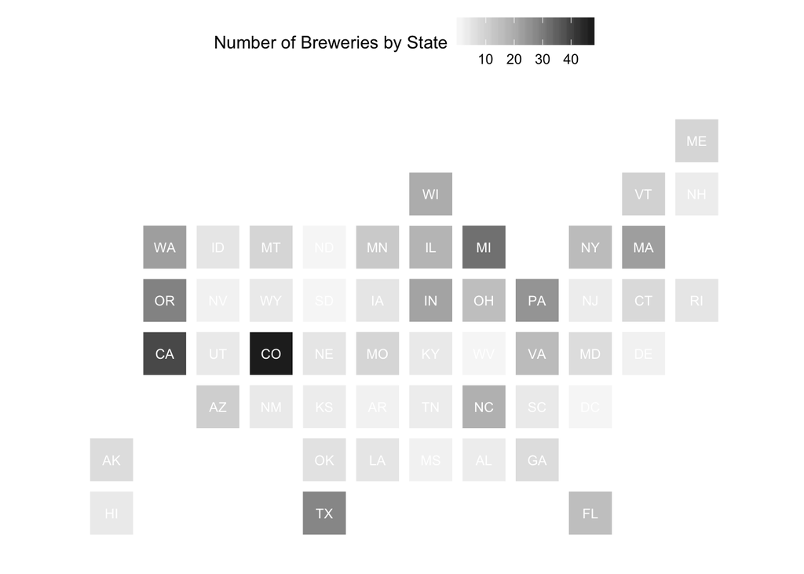

```r
#Plot Number of Breweries by State Bin
statebins_continuous(state_data = num_state, state_col = "region",
                     text_color = "white", value_col = "Freq",
                     brewer_pal="Greys", font_size = 3,
                     legend_title="Number of Breweries by State")
```

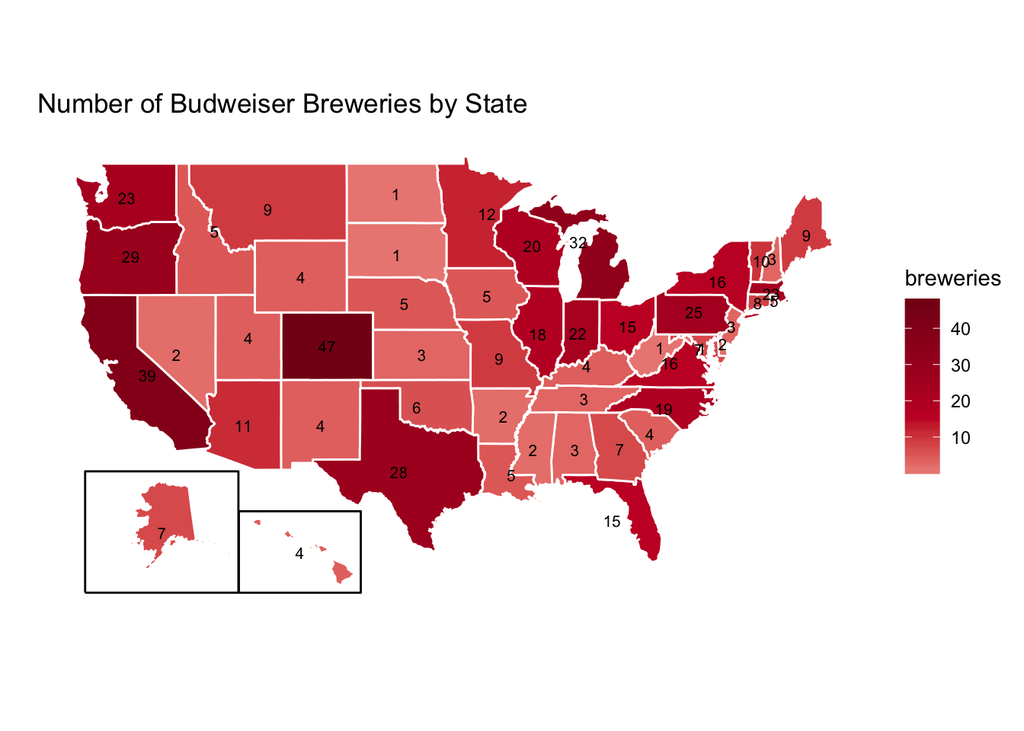

```r
#tidying for the fiftystater map
BreweriesCount = count(Breweries, State) #count up the occurrence in each state.
colnames(BreweriesCount)[2] = "breweries" #change "n" to "breweries"
BreweriesCount$state <- tolower(BreweriesCount$State) # lower case state column for fiftystater

#bring in data from fifty_states package for coordinates
data("fifty_states")

# map_id creates the aesthetic mapping to the state name column in BreweriesCount
p <- ggplot(BreweriesCount, aes(map_id = state)) +
     geom_map(aes(fill = breweries), color="white", map = fifty_states) +
     expand_limits(x = fifty_states$long, y = fifty_states$lat) +
     coord_map() +
  geom_text(data = fifty_states %>%
              group_by(id) %>%
              summarise(lat = mean(c(max(lat), min(lat))), long = mean(c(max(long), min(long)))) %>%
              mutate(state = id) %>%
              left_join(BreweriesCount, by = "state"), aes(x = long, y = lat, label = breweries), size=2.75) +
  scale_x_continuous(breaks = NULL) + scale_y_continuous(breaks = NULL) +
  labs(x = "", y = "", title = "Number of Budweiser Breweries by State") +
  theme(legend.position = "right",
  panel.background = element_blank())


# add border boxes to AK/HI & change gradient colors to white, budweiser red, budweiser secondary red
brewerybystate <- p + fifty_states_inset_boxes()+
  scale_fill_gradient2(low="white", mid="#C8102E", high="#860419", midpoint = 15)
brewerybystate
```

## Process of cleaning the data from geonames I created a new csv file to upload instead of making you run through the geoname one with 2million+ obs. The process is shown and has been commented out.

```r
#imported dataset: US.txt from geonames data US - http://download.geonames.org/export/dump/
#US <- read.delim("~/Downloads/US/US.txt", header=FALSE)

#using geonames data to create new dataframe with 4 columns
#us_cities <- cbind.data.frame(US$V2, US$V11, US$V5, US$V6)
#colnames(us_cities)[1] <- "City"
#colnames(us_cities)[2] <- "State"
#colnames(us_cities)[3] <- "lat"
#colnames(us_cities)[4] <- "lon"
#us_cities$cityandstate = paste(us_cities$City,us_cities$State) #creating a single column for city and state, because of duplicate city names
#us_cities$cityandstate <- as.character(us_cities$cityandstate) #make sure it's character before merge
#us_cities$cityandstate <- gsub("St", "Saint", us_cities$cityandstate) #fix abbreviations
#us_cities$cityandstate <- gsub("Mt", "Mount", us_cities$cityandstate)
#us_cities$cityandstate <- gsub(" ", "", us_cities$cityandstate) #remove whitespace
#us_cities$cityandstate<- gsub("\\.", "", us_cities$cityandstate) # remove period
#us_cities$cityandstate<- gsub("\\'", "", us_cities$cityandstate) # remove apostrophe

#brewcoord = Breweries #because i didn't want to screw up the original
#brewcoord$cityandstate= paste(brewcoord$City,brewcoord$state_code) #creating a new column
#num_city = as.data.frame(table(brewcoord$cityandstate)) #frequency of cities
#colnames(num_city)[1] <- "cityandstate"
#num_city$cityandstate <- as.character(num_city$cityandstate) #change to character to merge
#num_city$cityandstate <- gsub("St", "Saint", num_city$cityandstate) #fix abbreviations
#num_city$cityandstate <- gsub("Mt", "Mount", num_city$cityandstate)
#num_city$cityandstate<- gsub(" ", "", num_city$cityandstate)#remove whitespace
#num_city$cityandstate<- gsub("\\.", "", num_city$cityandstate) # remove period
#num_city$cityandstate<- gsub("\\'", "", num_city$cityandstate) # remove apostrophe

#finally... merging the two datasets
#Brews_City <- merge(num_city, us_cities,
#  by.x = "cityandstate",
#  all.x = TRUE,
#  all.y = FALSE)
#write.csv(Brews_City, "Brews_City.csv")

Brews_City <- read.csv("~/Desktop/Brews_City.csv")

#how many are missing lat?
sum(is.na(Brews_City$lat))
```

```
## [1] 10
```

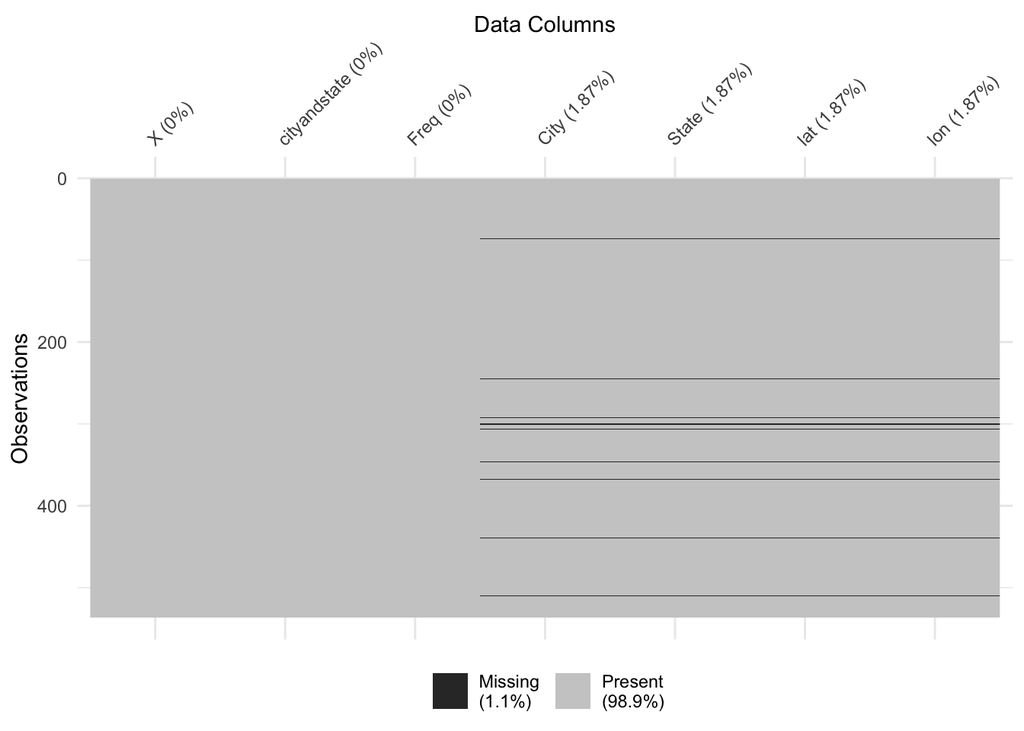

```r
#visualization of missing data
vis_miss(Brews_City) + xlab("Data Columns")
```

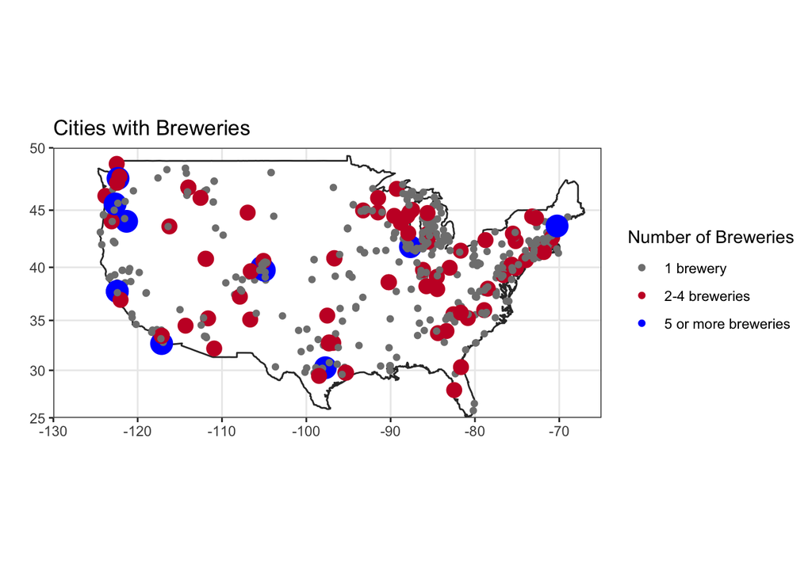

```r
#create new data set with lat and lon listed first
Brews_City2 = cbind.data.frame(Brews_City$lat, Brews_City$lon, Brews_City$Freq)
colnames(Brews_City2)[1] <- "lat"
colnames(Brews_City2)[2] <- "lon"
colnames(Brews_City2)[3] <- "freq"

#omit the 10 breweries that have NA values
Cities=na.omit(Brews_City2)

#create map with number of breweries by city
us <- map_data('usa') #data from library(maps)
Cities$freqfact <- cut(Cities$freq, breaks=c(0, 1, 4, Inf), labels=c("1 brewery", "2-4 breweries", "5 or more breweries")) #create new column for factor levels
Cities$freqfact <-as.factor(Cities$freqfact)  #changing to factor
ggplot()+
  geom_polygon(data=us, aes(x=long, y=lat, group = group), colour="grey20", fill="white") +
  geom_point(data = Cities, aes(x=lon, y = lat, color=freqfact, size=freqfact)) +     scale_color_manual(values=c("#808080","#C8102E","blue")) + scale_size_manual(values=c(1.5,4,6), guide=FALSE) + labs(color='Number of Breweries')  +
  coord_map(xlim=c(-130, -65), ylim=c(25,50)) + xlab("") + ylab("") + ggtitle("Cities with Breweries") +
  theme_bw()
```

# Question 2

**Merge beer data with the breweries data. Print the first 6 observations and the last six observations to check the merged file. (RMD only, this does not need to be included in the presentation or the deck.)**

```r
Beers <- read.csv("~/Desktop/Beers.csv") # read in beer data
colnames(Beers)[5] = "Brew_ID" #change "Brewery_ID" to "Brew_ID"

Beers_Breweries = merge(Breweries, Beers,"Brew_ID", all=TRUE) # merge while keeping all values
colnames(Beers_Breweries)[3] = "Brewery_Name"  # change "Name.x" to "Brewery"
colnames(Beers_Breweries)[5] = "State_Name"
colnames(Beers_Breweries)[6] = "Beer_Name"
head(Beers_Breweries, n=6) # first six observations
```

```
##   Brew_ID state_code       Brewery_Name        City State_Name
## 1       1         MN NorthGate Brewing  Minneapolis  Minnesota
## 2       1         MN NorthGate Brewing  Minneapolis  Minnesota
## 3       1         MN NorthGate Brewing  Minneapolis  Minnesota
## 4       1         MN NorthGate Brewing  Minneapolis  Minnesota
## 5       1         MN NorthGate Brewing  Minneapolis  Minnesota
## 6       1         MN NorthGate Brewing  Minneapolis  Minnesota
##       Beer_Name Beer_ID   ABV IBU                               Style
## 1    Wall's End    2690 0.048  19                   English Brown Ale
## 2    Stronghold    2688 0.060  25                     American Porter
## 3  Get Together    2692 0.045  50                        American IPA
## 4   Parapet ESB    2687 0.056  47 Extra Special / Strong Bitter (ESB)
## 5       Pumpion    2689 0.060  38                         Pumpkin Ale
## 6 Maggie's Leap    2691 0.049  26                  Milk / Sweet Stout
##   Ounces
## 1     16
## 2     16
## 3     16
## 4     16
## 5     16
## 6     16
```

```r
tail(Beers_Breweries,n=6) # last six obervations
```

```
##      Brew_ID state_code           Brewery_Name      City   State_Name
## 2405      98         PA Tröegs Brewing Company   Hershey Pennsylvania
## 2406      98         PA Tröegs Brewing Company   Hershey Pennsylvania
## 2407      99         CA        Mission Brewery San Diego   California
## 2408      99         CA        Mission Brewery San Diego   California
## 2409      99         CA        Mission Brewery San Diego   California
## 2410      99         CA        Mission Brewery San Diego   California
##                           Beer_Name Beer_ID   ABV IBU
## 2405                    Troegenator    2445 0.082  NA
## 2406         Troegenator Doublebock    1510 0.082  25
## 2407 El Conquistador Extra Pale Ale    1460 0.048  44
## 2408         Shipwrecked Double IPA    1459 0.092  75
## 2409                    Mission IPA    2441 0.068  66
## 2410                    Cortez Gold    2442 0.050  NA
##                               Style Ounces
## 2405                     Doppelbock     16
## 2406                     Doppelbock     16
## 2407        American Pale Ale (APA)     32
## 2408 American Double / Imperial IPA     32
## 2409                   American IPA     32
## 2410               Belgian Pale Ale     32
```

# Question 3

**Address the missing values in each column.**

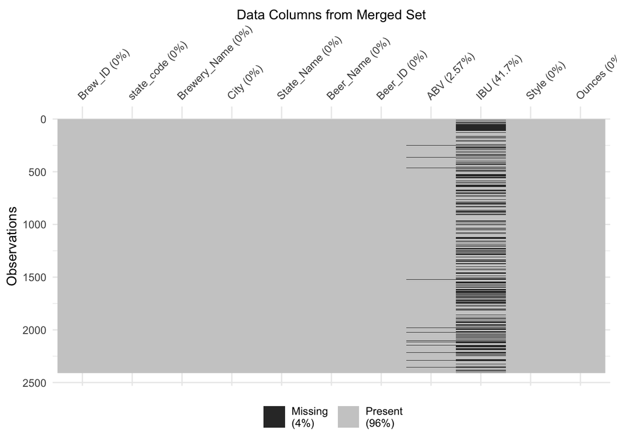

```r
#visualization of the observations with missing values by column
vis_miss(Beers_Breweries) + xlab("Data Columns from Merged Set")
```

```r
#replacing all NA values with the mean
Beers_Breweries <- na_mean(Beers_Breweries, option = "mean")

#addressing other suspect values
#remove can'd aid - looks to be a foundation and not a beer
Beers_Breweries <- Beers_Breweries[Beers_Breweries$Beer_ID != 1790, ]

# The CROWLER is a portmanteau of can + growler. It's a can that's the size of and is essentially a growler.
Beers_Breweries <- Beers_Breweries[Beers_Breweries$Beer_ID != 1796, ]

# Cedar Creek Special Release is just a marketing title and not a beer
Beers_Breweries <- Beers_Breweries[Beers_Breweries$Beer_ID != 2210, ]

# changing remaining missing values to the column mean
Beers_Breweries <- na_mean(Beers_Breweries, option = "mean")
```

## Question 4, ABV

**Compute the median alcohol content and international bitterness unit for each state. Plot a bar chart to compare.**

Looking at the barchart for median ABV by state, you can see the range is fairly consistant from slightly over 6% on the high end and about 5% on the low end with Utah being an outlier. Showing the median beer drinker is enjoying beer at a modest level of alcohol content. The bar chart of median IBU by state Shows WV enjoying a high level of bitterness compared to KS low tolerance for bitterness. There is a much larger range on this metric than the ABV indicating that geographic areas are more or less tolerant to the bitterness flavor profile, keep in mind the states with fairly consistant IBU medians in the center of the bar chart are heavily affected by the 40% of missing data and is due to us filling in the missing data with the mean.

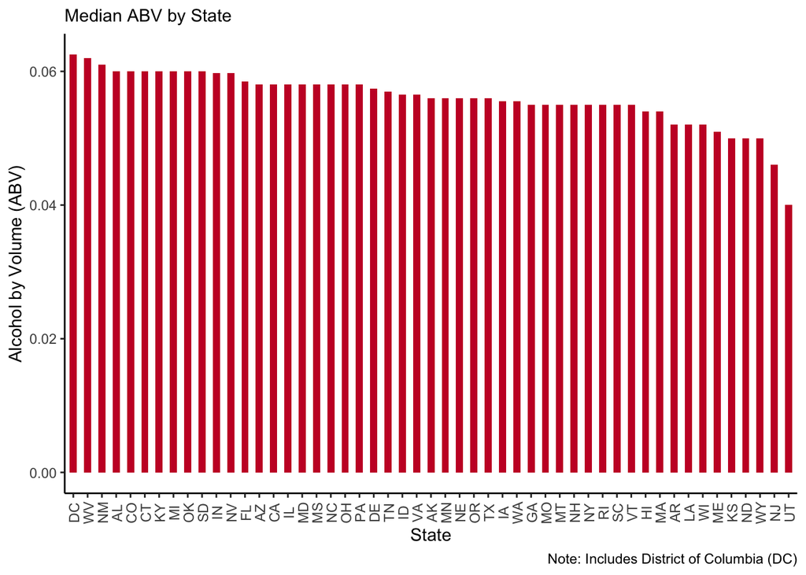

```r
#Median ABV & IBU by State
# create dataframe for median ABV by state, **note to MW - I changed this to avoid using the plyr package**
med_ABV <- Beers_Breweries %>%
  group_by(state_code) %>%
  summarize(medianABV = median(ABV))

#create dataset for median IBU by state
med_IBU<- Beers_Breweries %>%
  group_by(state_code) %>%
  summarize(medianIBU = median(IBU))

# merging median ABV and median IBU
med_bar = merge(med_ABV, med_IBU, by="state_code")
colnames(med_bar)[2] <- "Median_ABV"
colnames(med_bar)[3] <- "Median_IBU"

#Median ABV Map Viz
theme_set(theme_classic())
ggplot(med_bar, aes(x = reorder(state_code, -Median_ABV), y=Median_ABV)) + geom_bar(stat="identity", width = 0.5, fill="#C8102E") +
  labs(subtitle="Median ABV by State",
       caption="Note: Includes District of Columbia (DC)") +
  theme(axis.text.x = element_text(angle=90, vjust=0.6)) +
  xlab("State") + ylab("Alcohol by Volume (ABV)")
```

# Question 4, IBU

**Compute the median alcohol content and international bitterness unit for each state. Plot a bar chart to compare.**

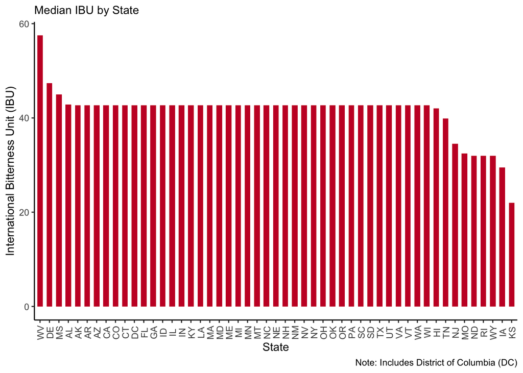

```r
#Median IBU Map Viz
theme_set(theme_classic())
ggplot(med_bar, aes(x = reorder(state_code, -Median_IBU), y=Median_IBU)) + geom_bar(stat="identity", width = 0.6, fill="#C8102E") +
  labs(subtitle="Median IBU by State",
       caption="Note: Includes District of Columbia (DC)") +
  theme(axis.text.x = element_text(angle=90, vjust=0.6)) +
  xlab("State") + ylab("International Bitterness Unit (IBU)")
```

# Question 5

**Which state has the maximum alcoholic (ABV) beer? Which state has the most bitter (IBU) beer?**

```r
library(plyr)
```

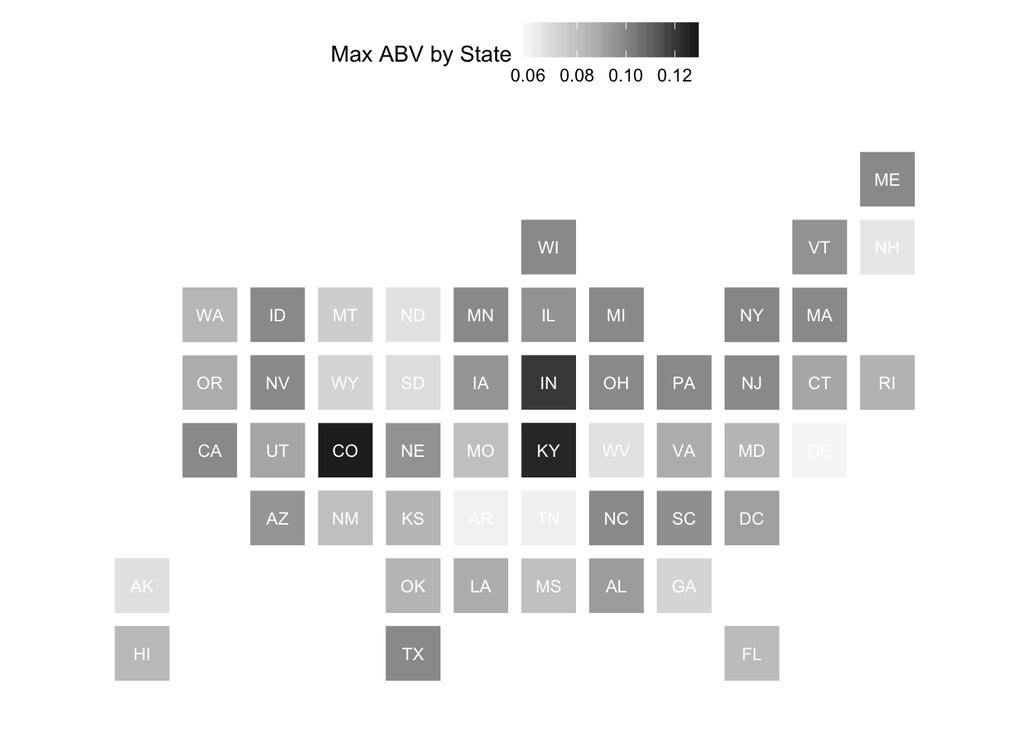

```r
#Maximums question
max_ABV = data.frame(ddply(Beers_Breweries,~state_code,summarise,max=max(ABV)))
max_IBU = data.frame(ddply(Beers_Breweries,~state_code,summarise,max=max(IBU)))
colnames(max_ABV)[1] <- "state_code"
colnames(max_IBU)[1] <- "state_code"
max_ABV = merge(max_ABV, num_state2, by="state_code")
max_IBU = merge(max_IBU, num_state2, by="state_code")
max_ABV$fullState <- as.character(max_ABV$fullState)
max_IBU$fullState <- as.character(max_IBU$fullState)

#Max Viz ABV
statebins_continuous(state_data = max_ABV, state_col = "fullState",
                     text_color = "white", value_col = "max",
                     brewer_pal="Greys", font_size = 3,
                     legend_title="Max ABV by State")
```

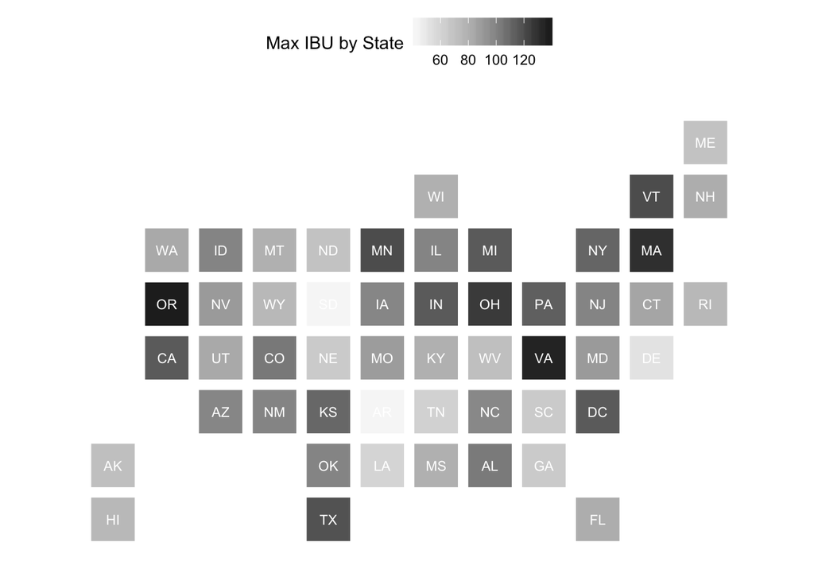

```r
#Max Viz IBU
statebins_continuous(state_data = max_IBU, state_col = "fullState",
                     text_color = "white", value_col = "max",
                     brewer_pal="Greys", font_size = 3,
                     legend_title="Max IBU by State")
```

```r
#Obs with Max ABV & Value
max(Beers_Breweries$ABV)
```

```
## [1] 0.128
```

```r
which.max(Beers_Breweries$ABV)
```

```
## [1] 2060
```

```r
#Upslope Brewing Company -  Lee Hill Series Vol. 5 - Belgian Style Quadrupel Ale    12.8

max(Beers_Breweries$IBU)
```

```
## [1] 138
```

```r
which.max(Beers_Breweries$IBU)
```

```
## [1] 1475
```

```r
#Astoria Brewing Company - Bitter Bitch Imperial IPA    138
```

# Question 6

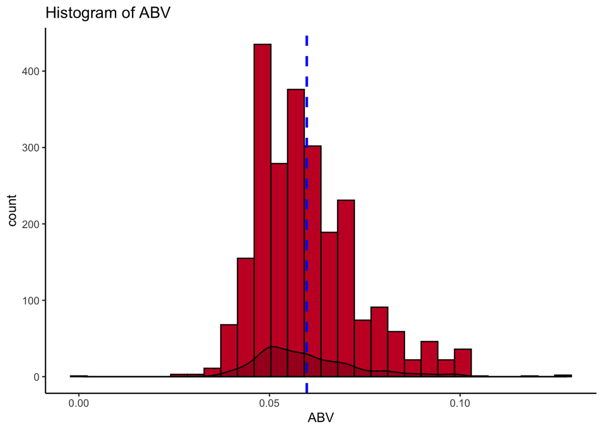

```r
#Statistics Summary for ABV
Beers_Breweries %>% ggplot(aes(x = ABV)) + geom_histogram(color="black", fill="#C8102E") + ggtitle("Histogram of ABV") + geom_vline(aes(xintercept=mean(ABV)), color="blue", linetype="dashed", size=1) + geom_density(alpha=.2, fill="black")
```

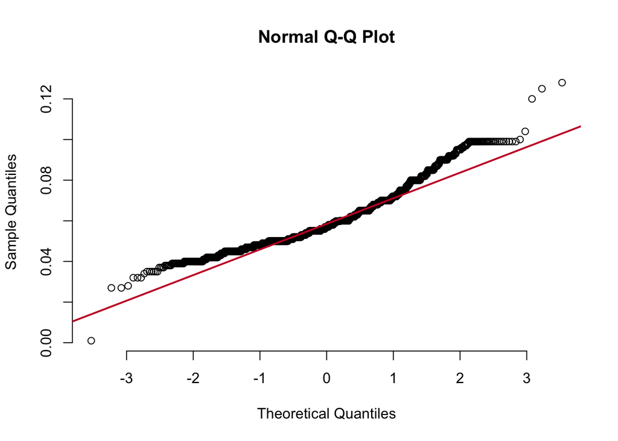

```r
qqnorm(Beers_Breweries$ABV, pch = 1, frame = FALSE)
qqline(Beers_Breweries$ABV, col = "#C8102E", lwd = 2)
```

# Question 7

**Is there an apparent relationship between the bitterness of the beer and its alcoholic content? Draw a scatter plot. Make your best judgment of a relationship and EXPLAIN your answer.**

Looking at ABV and IBU there is a positive linear correlation. As the beer has higher alcohol content it tends to have a higher IBU.  
More importantly, this graph shows the flavor profile that most breweries are producing their beers at. Around 5% ABV and 25 IBU we see a dense “sweet spot” of beers. If a brewery wanted to reach the largest number of consumers this is the ABV and IBU most beer drinkers enjoy. As you move away from this sweet spot the number of beers is substantially lower and less dense. We reccommend that your core SKUs that are trying to reach the most consumers and bring in the most revenue are close to this area, with much smaller percent of experimental beers outside the sweet spot. It is good to note at about 45 IBU there is a spot of high density and that is due to the mean being filled in for the missing IBU measurements and is not a accurate representation of the most sought after beer flavor profile.

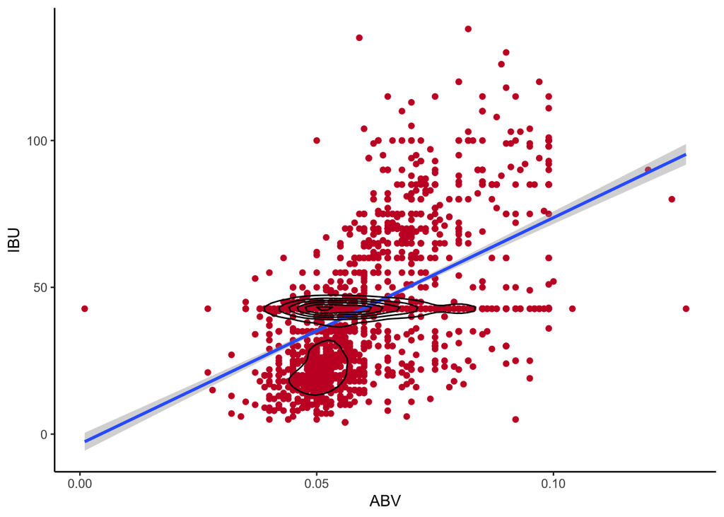

```r
#Scatter Plot Viz
ggplot(Beers_Breweries, aes(x=ABV, y=IBU)) + geom_point(color="#C8102E") + geom_smooth(method=lm) + geom_density_2d(color="black")
```

# Question 8

**Budweiser would also like to investigate the difference with respect to IBU and ABV between IPAs (India Pale Ales) and other types of Ale (any beer with “Ale” in its name other than IPA). You decide to use KNN classification to investigate this relationship. Provide statistical evidence one way or the other. You can of course assume your audience is comfortable with percentages … KNN is very easy to understand conceptually.**

With 84% accuracy(k=5), we are able to predict if an ale is an IPA or not using the given ales in the Beers dataset.

```r
#knn question - load libraries
library(class)
library(caret)
library(e1071)

IPAorAle = dplyr::filter(Beers_Breweries, grepl('IPA|Ale', Style))
IPAorAle$Type <- ifelse(grepl("IPA", IPAorAle$Style), "IPA", "Ale")
summary(IPAorAle)
```

```
##    Brew_ID           state_code                            Brewery_Name
##  Length:1534        Length:1534        Oskar Blues Brewery       :  39
##  Class :character   Class :character   Brewery Vivant            :  35
##  Mode  :character   Mode  :character   Sun King Brewing Company  :  23
##                                        Cigar City Brewing Company:  19
##                                        Hopworks Urban Brewery    :  19
##                                        Sixpoint Craft Ales       :  15
##                                        (Other)                   :1384
##            City       State_Name                      Beer_Name
##  Chicago     :  43   Length:1534        Nonstop Hef Hop    :  12
##  Portland    :  41   Class :character   Dale's Pale Ale    :   6
##  Grand Rapids:  39   Mode  :character   Dagger Falls IPA   :   3
##  San Diego   :  33                      312 Urban Pale Ale :   2
##  Denver      :  29                      312 Urban Wheat Ale:   2
##  Longmont    :  28                      Beach Blonde       :   2
##  (Other)     :1321                      (Other)            :1507
##     Beer_ID            ABV               IBU
##  Min.   :   1.0   Min.   :0.02700   Min.   :  4.00
##  1st Qu.: 783.2   1st Qu.:0.05200   1st Qu.: 40.00
##  Median :1450.0   Median :0.05977   Median : 42.71
##  Mean   :1421.1   Mean   :0.06127   Mean   : 47.17
##  3rd Qu.:2071.2   3rd Qu.:0.06900   3rd Qu.: 57.25
##  Max.   :2692.0   Max.   :0.09900   Max.   :138.00
##
##                             Style         Ounces          Type
##  American IPA                  :424   Min.   :12.00   Length:1534
##  American Pale Ale (APA)       :245   1st Qu.:12.00   Class :character
##  American Amber / Red Ale      :133   Median :12.00   Mode  :character
##  American Blonde Ale           :108   Mean   :13.58
##  American Double / Imperial IPA:105   3rd Qu.:16.00
##  American Pale Wheat Ale       : 97   Max.   :32.00
##  (Other)                       :422
```

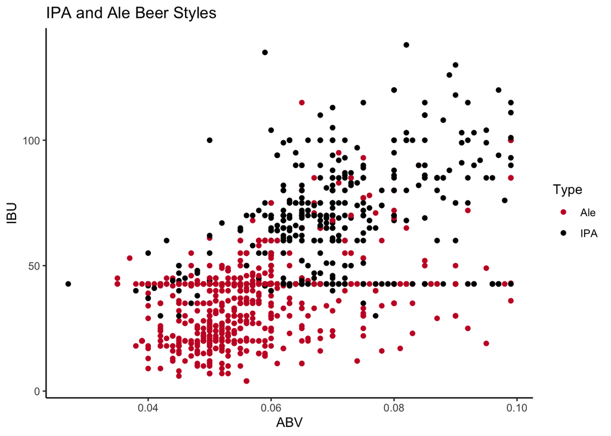

```r
set.seed(6)
splitPerc = .75
trainIndices = sample(1:dim(IPAorAle)[1],round(splitPerc * dim(IPAorAle)[1]))
train = IPAorAle[trainIndices,]
test = IPAorAle[-trainIndices,]

IPAorAle %>% ggplot(aes(x = ABV, IBU, color = Type)) + geom_point() + scale_color_manual(values = c("#C8102E", "#000000")) + ggtitle("IPA and Ale Beer Styles")
```

```r
# k = 5
classifications = knn(train[,c(8,9)],test[,c(8,9)],train$Type, prob = TRUE, k = 5)
table(test$Type,classifications)
```

```
##      classifications
##       Ale IPA
##   Ale 223  31
##   IPA  28 102
```

```r
confusionMatrix(table(test$Type,classifications))
```

```
## Confusion Matrix and Statistics
##
##      classifications
##       Ale IPA
##   Ale 223  31
##   IPA  28 102
##
##                Accuracy : 0.8464
##                  95% CI : (0.8063, 0.8809)
##     No Information Rate : 0.6536
##     P-Value [Acc > NIR] : <2e-16
##
##                   Kappa : 0.6589
##
##  Mcnemar's Test P-Value : 0.7946
##
##             Sensitivity : 0.8884
##             Specificity : 0.7669
##          Pos Pred Value : 0.8780
##          Neg Pred Value : 0.7846
##              Prevalence : 0.6536
##          Detection Rate : 0.5807
##    Detection Prevalence : 0.6615
##       Balanced Accuracy : 0.8277
##
##        'Positive' Class : Ale
##
```

# Question 9

**Knock their socks off! Find one other useful inference from the data that you feel Budweiser may be able to find value in. You must convince them why it is important and back up your conviction with appropriate statistical evidence.**

The boxplots of the selected style groups demonstrate that there is a difference in median ABVs by the style with IPAs, Stouts, and Porters having higher ABV medians.

[figure not shown]

```r
#histogram of American IPA ABV distribution
AmericanIPA <- Beers_Breweries[Beers_Breweries$Style == "American IPA",]
Beers_Breweries[Beers_Breweries$Style == "American IPA",] %>%
  ggplot(mapping = aes(x = ABV)) +
  geom_histogram(bins=15, color="black", fill="#C8102E",) + ggtitle("American IPA IBU distribution")
```

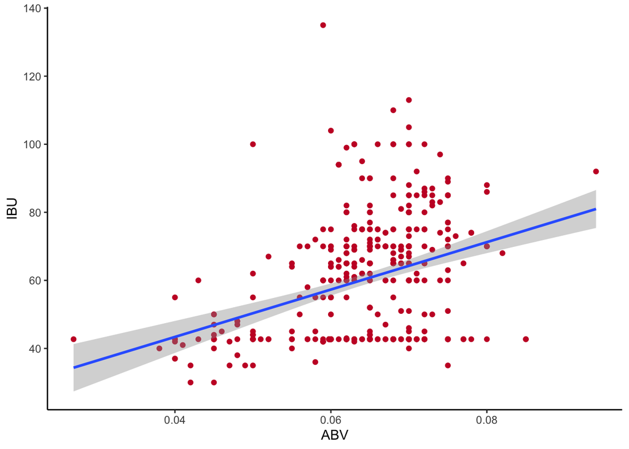

```r
#scatter plot American IPA ABV vs. IBU
ggplot(AmericanIPA, aes(x=ABV, y=IBU)) + geom_point(color="#C8102E") + geom_smooth(method=lm)
```

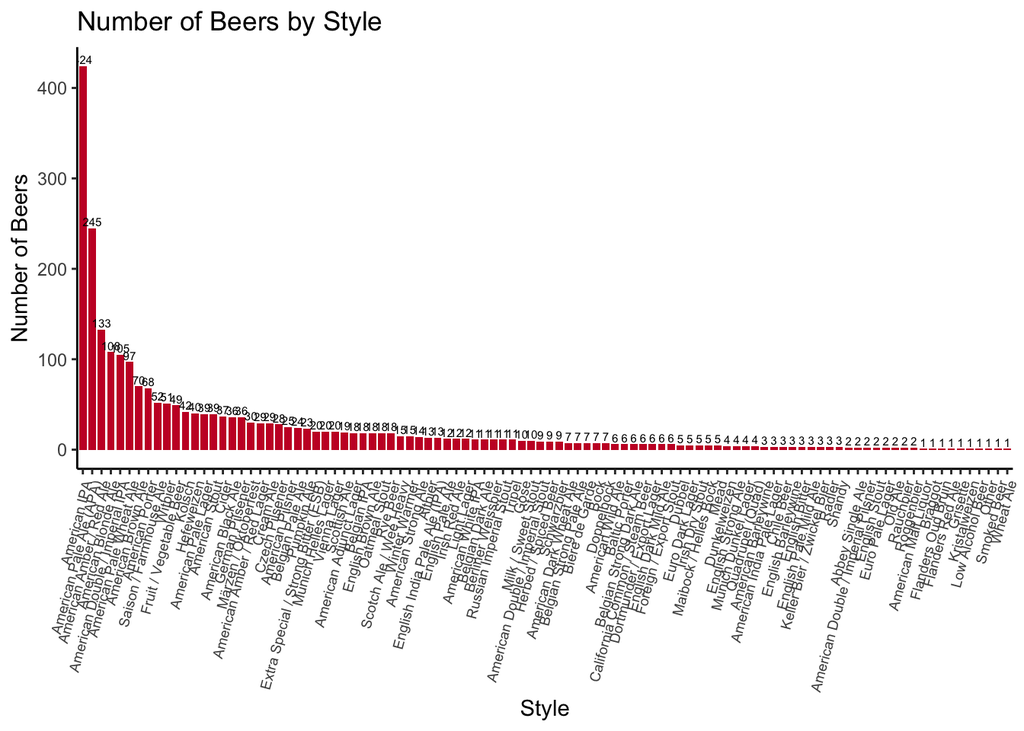

```r
#bar chart of number of beers per style
freqStyle = as.data.frame(table(Beers_Breweries$Style))
freqStyle %>%
  ggplot(aes(x=reorder(Var1, -Freq), y = Freq)) +
    geom_bar(stat="identity", fill="#C8102E", width=.8) + # budweiser red
    xlab("Style") + ylab("Number of Beers") + ggtitle("Number of Beers by Style") +
    geom_text(aes(label=Freq), vjust=-0.3, size=2) +
    theme(axis.text.x = element_text(angle = 75, size = 7, hjust = 1))
```

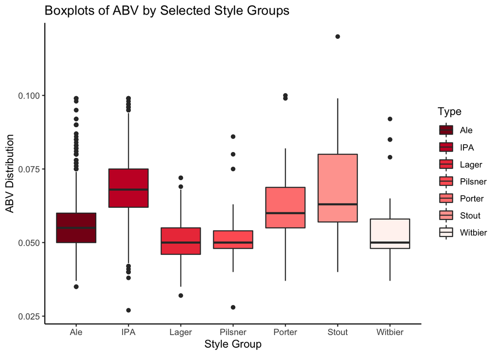

```r
#creating a new Type column to hold broader Style groups
Stout = dplyr::filter(Beers_Breweries, grepl('Stout', Style))
Stout$Type <- "Stout"

Porter = dplyr::filter(Beers_Breweries, grepl('Porter', Style))
Porter$Type <- "Porter"

Lager = dplyr::filter(Beers_Breweries, grepl('Lager', Style))
Lager$Type <- "Lager"

Witbier = dplyr::filter(Beers_Breweries, grepl('Witbier', Style))
Witbier$Type <- "Witbier"

Pilsner = dplyr::filter(Beers_Breweries, grepl('Pilsner|Pilsener', Style))
Pilsner$Type <- "Pilsner"

#merging dataframes back together
Beers_Types = rbind(Stout, Porter, IPAorAle, Lager, Pilsner, Witbier)

#plot ABV boxplot by selected style groups
p <- ggplot(Beers_Types, aes(x=Type, y=ABV, fill=Type)) +
  geom_boxplot() + xlab("Style Group") + ylab("ABV Distribution") + ggtitle("Boxplots of ABV by Selected Style Groups")

p + scale_fill_manual(values=c("#860419","#C8102E","#ED3F48", "#FF6263", "#FF8380","#FFA59E","#FFF4F1"))
```

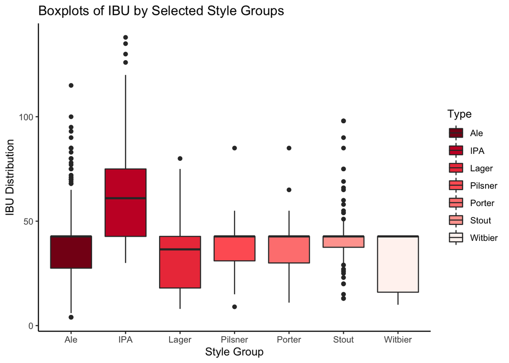

```r
#plot IBU boxplot by selected style groups
p <- ggplot(Beers_Types, aes(x=Type, y=IBU, fill=Type)) + xlab("Style Group") + ylab("IBU Distribution") + geom_boxplot() + ggtitle("Boxplots of IBU by Selected Style Groups")

p + scale_fill_manual(values=c("#860419","#C8102E","#ED3F48", "#FF6263", "#FF8380","#FFA59E","#FFF4F1"))
```

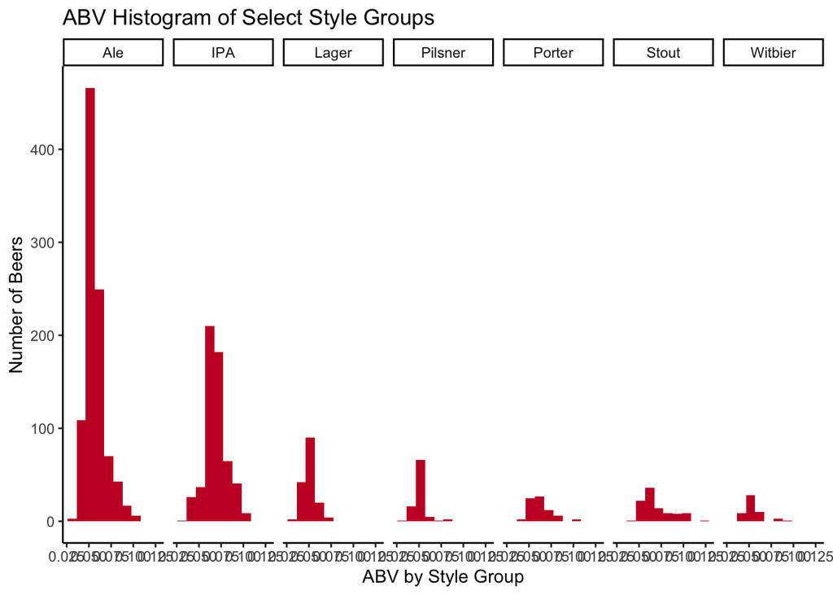

```r
#facet wrap by ABV
ggplot(data = Beers_Types) +
geom_histogram(mapping = aes(x = ABV), fill="#C8102E", bins=10) + ggtitle("ABV Histogram of Select Style Groups") + xlab("ABV by Style Group") + ylab("Number of Beers") +
facet_grid(~Type)
```

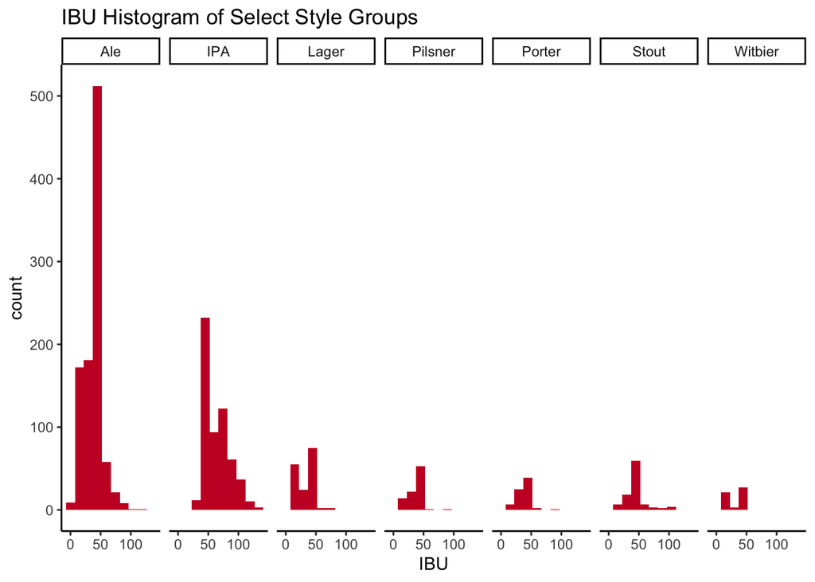

```r
#facet wrap by IBU
ggplot(data = Beers_Types,) +
geom_histogram(mapping = aes(x = IBU), fill="#C8102E", bins=10) + ggtitle("IBU Histogram of Select Style Groups")+
facet_grid(~Type)
```